# Affy

affy is a package by which Affymetrix array raw data can be read into the workspace but it first has to be called in. Make sure that they have been installed in your computer along with rmarkdown (use install.packages(‘rmarkdown’)) #to read more on rmarkdown go to https://bookdown.org/yihui/rmarkdown/installation.html. You first need to load the required libraries for microarray data analysis:

```r
library(affy)#to read, normalize and plot microarray data
library(limma)#to identify logFC and p-vals for genes
```

## ReadAffy() function

This is a key function of affy package to read .cel files and display the object and test how to show or not show the code

```r
getwd()
```

```
## [1] "/Users/faruk.ulutas/Desktop/R"
```

```r
a=ReadAffy()#make sure your .cel files are in working directory
a #prints the object called a show the contents
```

```
## AffyBatch object
## size of arrays=732x732 features (20 kb)
## cdf=HG-U133A_2 (22277 affyids)
## number of samples=6
## number of genes=22277
## annotation=hgu133a2
## notes=
```

## normalization step

The next step after reading the .cel files is to normalize them using rma(). This is a function that removes the background from the microarray and then applies quantile normalization to make the medians equal and then sums the probes that belongs to the same transcript all at once.

```r
eset = rma(a)#normalization command
```

```
## Background correcting
## Normalizing
## Calculating Expression
```

```r
eset
```

```
## ExpressionSet (storageMode: lockedEnvironment)
## assayData: 22277 features, 6 samples
##   element names: exprs
## protocolData
##   sampleNames: GSM430339.CEL.gz GSM430340.CEL.gz ... GSM430344.CEL.gz
##     (6 total)
##   varLabels: ScanDate
##   varMetadata: labelDescription
## phenoData
##   sampleNames: GSM430339.CEL.gz GSM430340.CEL.gz ... GSM430344.CEL.gz
##     (6 total)
##   varLabels: sample
##   varMetadata: labelDescription
## featureData: none
## experimentData: use 'experimentData(object)'
## Annotation: hgu133a2
```

```r
esetData = exprs(eset)#get the numeric expression data
head(esetData)#show top 6 rows
```

```
##           GSM430339.CEL.gz GSM430340.CEL.gz GSM430341.CEL.gz GSM430342.CEL.gz
## 1007_s_at         9.636190         9.794271        10.097330         9.968623
## 1053_at          10.765902        10.432095        10.650442        10.369464
## 117_at            6.334506         6.700273         6.431753         6.733726
## 121_at            9.112342         9.522277         9.296731         9.622098
## 1255_g_at         7.994388         7.804424         8.032174         7.706070
## 1294_at           6.709321         6.830287         6.649116         6.853811
##           GSM430343.CEL.gz GSM430344.CEL.gz
## 1007_s_at        10.239017         9.863419
## 1053_at          10.322990        10.092288
## 117_at            6.451959         6.622268
## 121_at            9.397789         9.557199
## 1255_g_at         8.178130         8.089055
## 1294_at           6.825342         6.897269
```

```r
tail(esetData)#show last 6 rows
```

```
##                 GSM430339.CEL.gz GSM430340.CEL.gz GSM430341.CEL.gz
## AFFX-ThrX-3_at         11.193417        10.630716        10.687279
## AFFX-ThrX-5_at         10.113258         9.552200         9.658630
## AFFX-ThrX-M_at         10.475080         9.825027         9.974199
## AFFX-TrpnX-3_at         3.939604         3.937771         3.966661
## AFFX-TrpnX-5_at         4.508487         4.438942         4.627003
## AFFX-TrpnX-M_at         4.632164         4.322202         4.282923
##                 GSM430342.CEL.gz GSM430343.CEL.gz GSM430344.CEL.gz
## AFFX-ThrX-3_at         10.727189        11.054753        10.725753
## AFFX-ThrX-5_at          9.640332         9.981745         9.699224
## AFFX-ThrX-M_at          9.931121        10.291227         9.994392
## AFFX-TrpnX-3_at         3.887770         4.050130         4.053084
## AFFX-TrpnX-5_at         4.522549         4.327959         4.389279
## AFFX-TrpnX-M_at         4.396220         4.435082         4.330601
```

## Boxplot of the .cel files before and after normalization

This is for GSE5390 the first three and last three files from GEO

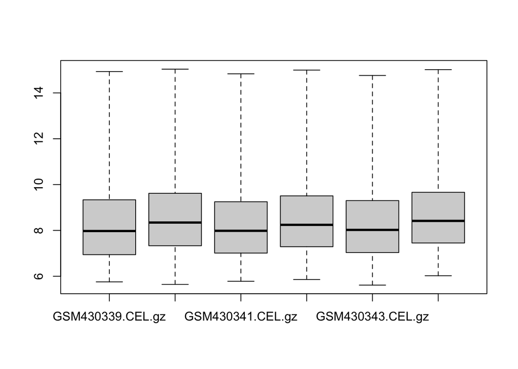

```r
boxplot(a[,1:6])#before normalization
```

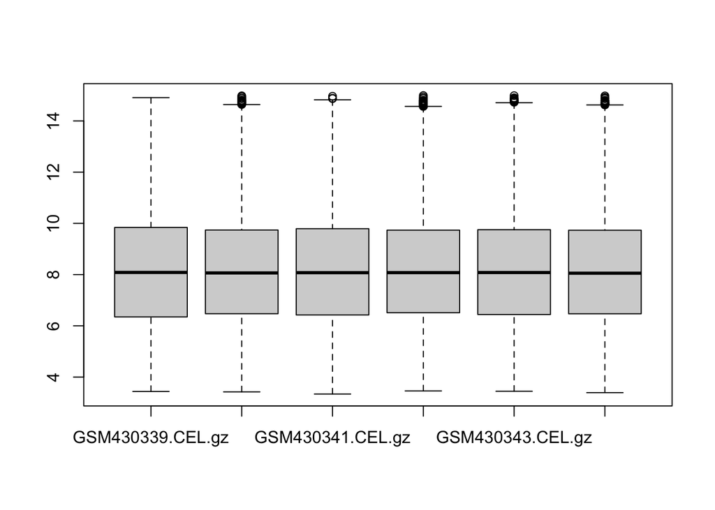

```r
boxplot(esetData[,1:6])#after normalization
```

#limma limma is a method that uses information about all of the data to calculate a p-value and logFC for each probeset

```r
label=c("DS","DS","DS","Euploid","Euploid","Euploid")
design <- model.matrix(~label)
design
```

```
##   (Intercept) labelEuploid
## 1           1            0
## 2           1            0
## 3           1            0
## 4           1            1
## 5           1            1
## 6           1            1
## attr(,"assign")
## [1] 0 1
## attr(,"contrasts")
## attr(,"contrasts")$label
## [1] "contr.treatment"
```

```r
fit <- lmFit(esetData, design) # fit
efit <- eBayes(fit) # empirical Bayes adjustment
tt <- topTable(efit, coef=2)#show the top 10 genes
tt#top 10 genes are:
```

```
##                  logFC  AveExpr         t      P.Value adj.P.Val         B
## 216003_at    0.6009801 5.108792  6.602826 0.0002971318 0.5966378 -2.664555
## 210261_at    0.4055757 5.247204  5.590261 0.0008103629 0.5966378 -2.821161
## 205957_at    0.4144058 7.234658  5.326243 0.0010746045 0.5966378 -2.872115
## 206239_s_at  0.3689330 5.075982  5.158761 0.0012914530 0.5966378 -2.907064
## 217376_at    0.4352662 6.851634  5.133437 0.0013282893 0.5966378 -2.912537
## 214046_at   -1.4127531 5.416690 -5.128324 0.0013358675 0.5966378 -2.913648
## 220125_at    0.4475106 6.844676  5.110637 0.0013624556 0.5966378 -2.917508
## 202822_at    0.5033347 6.331444  5.012642 0.0015208332 0.5966378 -2.939354
## 217419_x_at  0.4093554 8.668700  4.872795 0.0017833830 0.5966378 -2.971924
## 216307_at   -0.9138875 5.594453 -4.817500 0.0019007408 0.5966378 -2.985273
```